# Analisis de componentes principales(Cuestionario Presidente)

Francisco Flor

2023

## 📦 Carga de Librerías

```r
library(foreign)
library(openxlsx)
library(rmarkdown)
library(knitr)
library(psych)
library(ggplot2)
library(readr)
```

## 📁 Importación de Datos

```
##  [1] "x1"  "x2"  "x3"  "x4"  "x5"  "x6"  "x7"  "x8"  "x9"  "x10" "x11"
```

X1 -> El presidente debe de poseer al menos un título universitario para poder ejercer

X2 -> El mínimo de edad que una persona debe de tener para poder ser presidente, debe de ser mayor o igual a 35 años.

X3 -> Para que una persona pueda ser presidente, es necesario que tenga experiencia política.

X4 -> Para que una persona pueda ser presidente, es necesario que tenga experiencia en el sector privado.

X5 -> La persona que usted elija para ser presidente, debe tener una orientación socialista.

X6 -> Mientras menos restricciones imponga el Estado para hacer negocios, mejores resultados puede tener el país en términos económicos y por tanto, la persona que elija como presidente deberá tener esa cualidad.

X7 -> El plan de trabajo del nuevo presidente deberá considerar como punto importante, bajar los impuestos progresivamente.

X8 -> El carisma es un factor importante al momento de elegir al presidente, pues esto indica que es una persona abierta al dialogo.

X9 ->Mantener la dolarización es un pensamiento que el nuevo presidente debe de tener.

X10 -> En el plan de trabajo presidencial, se debe de considerar a la educación como un factor importante y de corto plazo.

X11 ->Los incentivos tributarios para nuevas empresas o emprendimientos deberán de ser considerados por el nuevo presidente

1.-Muy desacuerdo 1

2.-Desacuerdo 2

3.-Parcialmente de Acuerdo 3

4.-De acuerdo 4

5.-Muy de acuerdo 5

```r
head(DATAPRINCIPAL, 10)
```

```
##    x1 x2 x3 x4 x5 x6 x7 x8 x9 x10 x11
## 1   5  4  3  3  2  4  3  4  5   5   5
## 2   1  2  3  1  1  5  5  2  5   5   5
## 3   5  4  4  3  2  2  2  4  4   4   4
## 4   4  3  3  2  3  4  1  3  4   4   4
## 5   5  5  5  3  1  5  4  5  5   5   5
## 6   5  4  4  4  1  5  2  3  5   5   5
## 7   5  5  5  3  3  4  3  5  5   3   4
## 8   5  5  5  3  3  5  5  3  5   5   5
## 9   5  4  3  4  3  5  4  2  5   4   4
## 10  5  4  3  1  1  5  3  5  5   5   5
```

## 📊 Análisis Inicial

### Correlación

```r
cor(DATAPRINCIPAL)
```

```
##              x1           x2          x3           x4          x5          x6
## x1   1.00000000  0.353812315  0.15147800  0.379289130  0.33202344 -0.14018306
## x2   0.35381232  1.000000000  0.16241977  0.152888740  0.14914730 -0.03263287
## x3   0.15147800  0.162419768  1.00000000  0.177733841  0.17855675  0.31147331
## x4   0.37928913  0.152888740  0.17773384  1.000000000  0.54094959  0.25746268
## x5   0.33202344  0.149147302  0.17855675  0.540949590  1.00000000  0.08462149
## x6  -0.14018306 -0.032632866  0.31147331  0.257462678  0.08462149  1.00000000
## x7  -0.13685676 -0.028924205  0.24981785  0.102140692 -0.09802752  0.39124498
## x8   0.20134867  0.310196500  0.46657817  0.262397695  0.18197186  0.20974309
## x9  -0.20696411 -0.005041953 -0.01665841  0.001634768 -0.11139451  0.24023700
## x10 -0.01151634 -0.152808973  0.16939876  0.277716912  0.04880188  0.59059361
## x11 -0.12097352  0.021120843  0.25296128 -0.066768764 -0.21195695  0.52685785
##               x7           x8           x9         x10         x11
## x1  -0.136856764  0.201348671 -0.206964109 -0.01151634 -0.12097352
## x2  -0.028924205  0.310196500 -0.005041953 -0.15280897  0.02112084
## x3   0.249817854  0.466578170 -0.016658410  0.16939876  0.25296128
## x4   0.102140692  0.262397695  0.001634768  0.27771691 -0.06676876
## x5  -0.098027520  0.181971860 -0.111394513  0.04880188 -0.21195695
## x6   0.391244980  0.209743088  0.240236996  0.59059361  0.52685785
## x7   1.000000000 -0.005279945  0.037576683  0.17200102  0.29770927
## x8  -0.005279945  1.000000000 -0.156021288  0.32266137  0.18227884
## x9   0.037576683 -0.156021288  1.000000000  0.12538151 -0.02743900
## x10  0.172001023  0.322661371  0.125381514  1.00000000  0.25604754
## x11  0.297709266  0.182278838 -0.027438999  0.25604754  1.00000000
```

### Alfa de Cronbach

```r
psych::alpha(DATAPRINCIPAL)
```

```
##
## Reliability analysis
## Call: psych::alpha(x = DATAPRINCIPAL)
##
##   raw_alpha std.alpha G6(smc) average_r S/N   ase mean   sd median_r
##       0.65      0.64    0.74      0.14 1.8 0.085  3.9 0.51     0.16
##
##     95% confidence boundaries
##          lower alpha upper
## Feldt     0.45  0.65  0.80
## Duhachek  0.48  0.65  0.82
##
##  Reliability if an item is dropped:
##     raw_alpha std.alpha G6(smc) average_r S/N alpha se var.r med.r
## x1       0.64      0.64    0.73      0.15 1.8    0.088 0.036  0.17
## x2       0.65      0.64    0.73      0.15 1.7    0.085 0.042  0.18
## x3       0.59      0.58    0.70      0.12 1.4    0.101 0.043  0.13
## x4       0.59      0.58    0.69      0.12 1.4    0.099 0.040  0.15
## x5       0.64      0.63    0.72      0.14 1.7    0.088 0.037  0.17
## x6       0.59      0.56    0.66      0.11 1.3    0.098 0.034  0.15
## x7       0.65      0.63    0.73      0.15 1.7    0.084 0.041  0.17
## x8       0.60      0.59    0.69      0.12 1.4    0.099 0.040  0.15
## x9       0.68      0.67    0.76      0.17 2.1    0.080 0.038  0.18
## x10      0.62      0.60    0.70      0.13 1.5    0.093 0.039  0.15
## x11      0.64      0.63    0.72      0.14 1.7    0.088 0.037  0.16
##
##  Item statistics
##      n raw.r std.r r.cor r.drop mean   sd
## x1  35  0.35  0.35 0.260  0.211  4.7 0.80
## x2  35  0.39  0.38 0.274  0.201  3.6 1.14
## x3  35  0.65  0.61 0.555  0.465  3.5 1.38
## x4  35  0.62  0.60 0.575  0.465  3.5 1.17
## x5  35  0.45  0.41 0.339  0.254  2.5 1.22
## x6  35  0.63  0.67 0.697  0.505  4.3 1.02
## x7  35  0.39  0.39 0.280  0.190  3.5 1.17
## x8  35  0.61  0.58 0.546  0.443  3.5 1.22
## x9  35  0.13  0.17 0.018 -0.024  4.4 0.88
## x10 35  0.51  0.55 0.516  0.372  4.4 0.92
## x11 35  0.35  0.41 0.346  0.234  4.4 0.70
##
## Non missing response frequency for each item
##        1    2    3    4    5 miss
## x1  0.03 0.00 0.03 0.14 0.80    0
## x2  0.03 0.17 0.20 0.34 0.26    0
## x3  0.09 0.17 0.26 0.11 0.37    0
## x4  0.09 0.06 0.40 0.23 0.23    0
## x5  0.26 0.20 0.37 0.09 0.09    0
## x6  0.03 0.06 0.06 0.31 0.54    0
## x7  0.03 0.17 0.34 0.17 0.29    0
## x8  0.06 0.14 0.31 0.20 0.29    0
## x9  0.00 0.03 0.17 0.20 0.60    0
## x10 0.03 0.00 0.11 0.23 0.63    0
## x11 0.00 0.03 0.03 0.43 0.51    0
```

el raw_alpha es 0.65, por tanto si se acepta porque es mayor a 0.5-

### KMO

```r
KMO(DATAPRINCIPAL)
```

```
## Kaiser-Meyer-Olkin factor adequacy
## Call: KMO(r = DATAPRINCIPAL)
## Overall MSA =  0.59
## MSA for each item =
##   x1   x2   x3   x4   x5   x6   x7   x8   x9  x10  x11
## 0.64 0.49 0.64 0.65 0.59 0.60 0.62 0.57 0.38 0.58 0.61
```

puesto que KMO(0.59) es mayor que 0.5 puedo continuar

## 🔍 Análisis de Componentes Principales (ACP)

```r
macp1 <- princomp(DATAPRINCIPAL, scores=TRUE, cor=TRUE)
summary(macp1)
```

```
## Importance of components:
##                           Comp.1    Comp.2    Comp.3     Comp.4     Comp.5
## Standard deviation     1.6441137 1.4852209 1.1366008 1.00165569 0.95945046
## Proportion of Variance 0.2457373 0.2005346 0.1174420 0.09121037 0.08368593
## Cumulative Proportion  0.2457373 0.4462719 0.5637139 0.65492423 0.73861015
##                            Comp.6     Comp.7     Comp.8     Comp.9    Comp.10
## Standard deviation     0.87275161 0.78132754 0.75859212 0.62860731 0.55062253
## Proportion of Variance 0.06924503 0.05549752 0.05231473 0.03592247 0.02756229
## Cumulative Proportion  0.80785519 0.86335271 0.91566743 0.95158990 0.97915219
##                           Comp.11
## Standard deviation     0.47887984
## Proportion of Variance 0.02084781
## Cumulative Proportion  1.00000000
```

```r
loadings(macp1)
```

```
##
## Loadings:
##     Comp.1 Comp.2 Comp.3 Comp.4 Comp.5 Comp.6 Comp.7 Comp.8 Comp.9 Comp.10
## x1   0.147  0.476                       0.401  0.321  0.607  0.112  0.251
## x2   0.144  0.313  0.367  0.584         0.293        -0.392  0.257 -0.268
## x3   0.389         0.298               -0.640         0.425        -0.369
## x4   0.348  0.299 -0.408         0.186  0.124        -0.117 -0.649 -0.362
## x5   0.215  0.410 -0.354 -0.111  0.165 -0.213 -0.527         0.336  0.371
## x6   0.448 -0.314 -0.169                0.150 -0.244         0.234 -0.162
## x7   0.243 -0.284                0.732         0.402 -0.238         0.300
## x8   0.383  0.174  0.305        -0.453 -0.226  0.170 -0.336 -0.279  0.454
## x9         -0.228 -0.385  0.771 -0.134 -0.142         0.214 -0.153  0.294
## x10  0.385 -0.197 -0.289 -0.193 -0.405  0.197  0.362         0.373 -0.118
## x11  0.288 -0.341  0.351                0.383 -0.478  0.237 -0.287  0.194
##     Comp.11
## x1   0.180
## x2  -0.144
## x3  -0.129
## x4
## x5  -0.194
## x6   0.711
## x7
## x8   0.213
## x9
## x10 -0.450
## x11 -0.349
##
##                Comp.1 Comp.2 Comp.3 Comp.4 Comp.5 Comp.6 Comp.7 Comp.8 Comp.9
## SS loadings     1.000  1.000  1.000  1.000  1.000  1.000  1.000  1.000  1.000
## Proportion Var  0.091  0.091  0.091  0.091  0.091  0.091  0.091  0.091  0.091
## Cumulative Var  0.091  0.182  0.273  0.364  0.455  0.545  0.636  0.727  0.818
##                Comp.10 Comp.11
## SS loadings      1.000   1.000
## Proportion Var   0.091   0.091
## Cumulative Var   0.909   1.000
```

-Solo nos quedamos con los componentes que tengan varianza mayor a 1(Varianza es Standard Deviation al cuadrado)

- Por tanto, nos quedamos con 4 componentes para la continuacion del proceso.

### Scree Plot

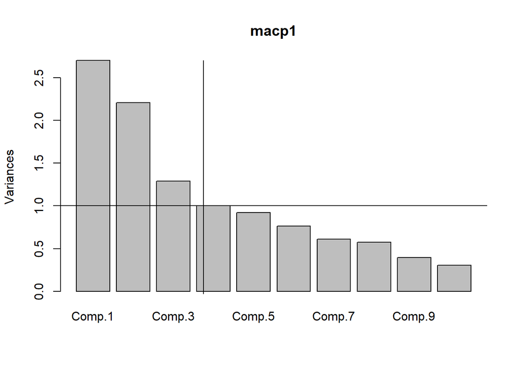

```r
plot(macp1)
abline(h=1, v=4)
```

### Biplot

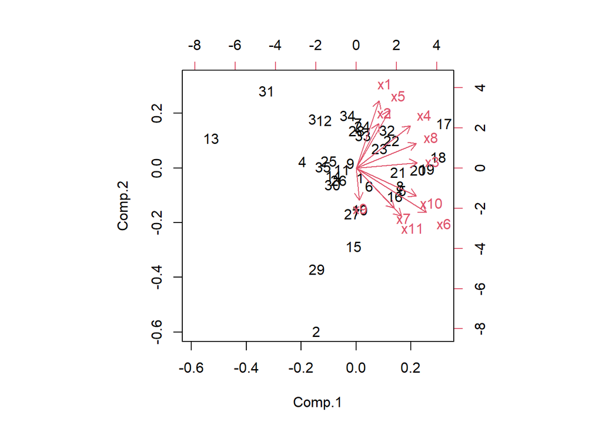

```r
biplot(macp1)
```

## 🎯 Análisis Factorial (4 Factores)

```r
maf1 <- factanal(DATAPRINCIPAL, factor=4, rotation="none")
maf1$loadings
```

```
##
## Loadings:
##     Factor1 Factor2 Factor3 Factor4
## x1           0.564  -0.163
## x2  -0.145   0.418           0.236
## x3   0.191   0.361   0.271   0.371
## x4   0.288   0.638          -0.303
## x5           0.657          -0.333
## x6   0.647           0.739
## x7   0.198           0.362
## x8   0.327   0.503           0.514
## x9   0.139  -0.199   0.191  -0.183
## x10  0.995
## x11  0.290  -0.155   0.465   0.362
##
##                Factor1 Factor2 Factor3 Factor4
## SS loadings      1.802   1.785   1.056   0.829
## Proportion Var   0.164   0.162   0.096   0.075
## Cumulative Var   0.164   0.326   0.422   0.498
```

```r
maf2 <- factanal(DATAPRINCIPAL, factors=4, rotation="varimax", scores="regression")
maf2$loadings
```

```
##
## Loadings:
##     Factor1 Factor2 Factor3 Factor4
## x1  -0.242   0.435   0.313
## x2           0.186   0.433  -0.193
## x3   0.292   0.129   0.523
## x4           0.733   0.138   0.167
## x5           0.730   0.117
## x6   0.922   0.179           0.287
## x7   0.422
## x8   0.102   0.146   0.721   0.269
## x9   0.244          -0.256
## x10  0.326   0.123           0.934
## x11  0.583  -0.239   0.221
##
##                Factor1 Factor2 Factor3 Factor4
## SS loadings      1.697   1.438   1.228   1.110
## Proportion Var   0.154   0.131   0.112   0.101
## Cumulative Var   0.154   0.285   0.397   0.498
```

como despues de rotar, aun no se cumple los requisitos. Por tanto, se debe analizar si es posible eliminar alguna de las variables.

## 🧹 Ajuste de Variables

```r
loadings(macp1)
```

```
##
## Loadings:
##     Comp.1 Comp.2 Comp.3 Comp.4 Comp.5 Comp.6 Comp.7 Comp.8 Comp.9 Comp.10
## x1   0.147  0.476                       0.401  0.321  0.607  0.112  0.251
## x2   0.144  0.313  0.367  0.584         0.293        -0.392  0.257 -0.268
## x3   0.389         0.298               -0.640         0.425        -0.369
## x4   0.348  0.299 -0.408         0.186  0.124        -0.117 -0.649 -0.362
## x5   0.215  0.410 -0.354 -0.111  0.165 -0.213 -0.527         0.336  0.371
## x6   0.448 -0.314 -0.169                0.150 -0.244         0.234 -0.162
## x7   0.243 -0.284                0.732         0.402 -0.238         0.300
## x8   0.383  0.174  0.305        -0.453 -0.226  0.170 -0.336 -0.279  0.454
## x9         -0.228 -0.385  0.771 -0.134 -0.142         0.214 -0.153  0.294
## x10  0.385 -0.197 -0.289 -0.193 -0.405  0.197  0.362         0.373 -0.118
## x11  0.288 -0.341  0.351                0.383 -0.478  0.237 -0.287  0.194
##     Comp.11
## x1   0.180
## x2  -0.144
## x3  -0.129
## x4
## x5  -0.194
## x6   0.711
## x7
## x8   0.213
## x9
## x10 -0.450
## x11 -0.349
##
##                Comp.1 Comp.2 Comp.3 Comp.4 Comp.5 Comp.6 Comp.7 Comp.8 Comp.9
## SS loadings     1.000  1.000  1.000  1.000  1.000  1.000  1.000  1.000  1.000
## Proportion Var  0.091  0.091  0.091  0.091  0.091  0.091  0.091  0.091  0.091
## Cumulative Var  0.091  0.182  0.273  0.364  0.455  0.545  0.636  0.727  0.818
##                Comp.10 Comp.11
## SS loadings      1.000   1.000
## Proportion Var   0.091   0.091
## Cumulative Var   0.909   1.000
```

### Eliminación de la variable (en este caso X10)

```r
DATA2 <- cbind(DATAPRINCIPAL[1:35,1:9],DATAPRINCIPAL[1:35,11])
macp2 <- princomp(DATA2, scores=TRUE, cor=TRUE)
summary(macp2)
```

```
## Importance of components:
##                           Comp.1    Comp.2    Comp.3     Comp.4     Comp.5
## Standard deviation     1.5689963 1.4474175 1.1069204 0.99538854 0.90358656
## Proportion of Variance 0.2461749 0.2095017 0.1225273 0.09907983 0.08164687
## Cumulative Proportion  0.2461749 0.4556767 0.5782039 0.67728378 0.75893065
##                            Comp.6     Comp.7     Comp.8     Comp.9    Comp.10
## Standard deviation     0.84798633 0.75918458 0.70973503 0.56718436 0.53835821
## Proportion of Variance 0.07190808 0.05763612 0.05037238 0.03216981 0.02898296
## Cumulative Proportion  0.83083873 0.88847485 0.93884723 0.97101704 1.00000000
```

```r
loadings(macp2)
```

```
##
## Loadings:
##                         Comp.1 Comp.2 Comp.3 Comp.4 Comp.5 Comp.6 Comp.7 Comp.8
## x1                       0.314  0.388                0.375  0.139  0.658  0.157
## x2                       0.287  0.180  0.289  0.579  0.422        -0.414 -0.263
## x3                       0.420 -0.177  0.188        -0.286 -0.544  0.400 -0.296
## x4                       0.426  0.164 -0.453 -0.135         0.138         0.419
## x5                       0.350  0.309 -0.388 -0.205 -0.168        -0.199 -0.583
## x6                       0.304 -0.467 -0.262                0.320
## x7                       0.157 -0.411 -0.110 -0.240  0.581 -0.500 -0.181  0.131
## x8                       0.431         0.349  0.107 -0.451        -0.282  0.491
## x9                             -0.207 -0.491  0.727 -0.102         0.222
## DATAPRINCIPAL[1:35, 11]  0.177 -0.482  0.271                0.549  0.162 -0.188
##                         Comp.9 Comp.10
## x1                       0.352
## x2                      -0.135 -0.166
## x3                      -0.318 -0.176
## x4                      -0.597
## x5                       0.250  0.344
## x6                       0.365 -0.614
## x7                       0.206  0.237
## x8                       0.309  0.246
## x9                              0.320
## DATAPRINCIPAL[1:35, 11] -0.250  0.474
##
##                Comp.1 Comp.2 Comp.3 Comp.4 Comp.5 Comp.6 Comp.7 Comp.8 Comp.9
## SS loadings       1.0    1.0    1.0    1.0    1.0    1.0    1.0    1.0    1.0
## Proportion Var    0.1    0.1    0.1    0.1    0.1    0.1    0.1    0.1    0.1
## Cumulative Var    0.1    0.2    0.3    0.4    0.5    0.6    0.7    0.8    0.9
##                Comp.10
## SS loadings        1.0
## Proportion Var     0.1
## Cumulative Var     1.0
```

### Factorial con DATA2 (3 componentes)

```r
maf3 <- factanal(DATA2, factor=3, rotation="none")
maf3$loadings
```

```
##
## Loadings:
##                         Factor1 Factor2 Factor3
## x1                       0.583  -0.133
## x2                       0.360           0.264
## x3                       0.314   0.330   0.418
## x4                       0.678   0.269  -0.227
## x5                       0.677          -0.260
## x6                               0.985
## x7                               0.400
## x8                       0.448   0.227   0.497
## x9                      -0.186   0.234  -0.219
## DATAPRINCIPAL[1:35, 11] -0.202   0.537   0.374
##
##                Factor1 Factor2 Factor3
## SS loadings      1.770   1.732   0.811
## Proportion Var   0.177   0.173   0.081
## Cumulative Var   0.177   0.350   0.431
```

```r
maf4 <- factanal(DATA2, factors=3, rotation="varimax", scores="regression")
maf4$loadings
```

```
##
## Loadings:
##                         Factor1 Factor2 Factor3
## x1                      -0.217   0.415   0.378
## x2                               0.156   0.417
## x3                       0.332   0.118   0.508
## x4                       0.113   0.737   0.162
## x5                               0.714   0.140
## x6                       0.959   0.217
## x7                       0.418
## x8                       0.221   0.164   0.651
## x9                       0.226          -0.293
## DATAPRINCIPAL[1:35, 11]  0.614  -0.240   0.186
##
##                Factor1 Factor2 Factor3
## SS loadings      1.748   1.397   1.169
## Proportion Var   0.175   0.140   0.117
## Cumulative Var   0.175   0.314   0.431
```

### Eliminación de X5

```r
DATA3 <- cbind(DATA2[1:35,1:4], DATA2[1:35,6:9], DATA2[1:35,10])
macp3 <- princomp(DATA3, scores=TRUE, cor=TRUE)
summary(macp3)
```

```
## Importance of components:
##                           Comp.1    Comp.2    Comp.3    Comp.4    Comp.5
## Standard deviation     1.5250784 1.3756122 1.0480319 0.9667036 0.8886236
## Proportion of Variance 0.2584294 0.2102566 0.1220412 0.1038351 0.0877391
## Cumulative Proportion  0.2584294 0.4686859 0.5907271 0.6945622 0.7823013
##                            Comp.6     Comp.7     Comp.8     Comp.9
## Standard deviation     0.84762970 0.75425967 0.60366316 0.55452247
## Proportion of Variance 0.07983068 0.06321196 0.04048991 0.03416613
## Cumulative Proportion  0.86213200 0.92534396 0.96583387 1.00000000
```

```r
loadings(macp3)
```

```
##
## Loadings:
##                 Comp.1 Comp.2 Comp.3 Comp.4 Comp.5 Comp.6 Comp.7 Comp.8 Comp.9
## x1               0.150  0.547  0.117  0.205  0.236  0.150  0.591  0.401  0.186
## x2               0.219  0.381        -0.501  0.603        -0.298 -0.307
## x3               0.469        -0.147 -0.128 -0.281 -0.533  0.453 -0.411
## x4               0.307  0.270  0.497  0.478 -0.173  0.175 -0.255 -0.275 -0.396
## x6               0.454 -0.352  0.198                0.326        -0.125  0.707
## x7               0.307 -0.327         0.384  0.485 -0.519 -0.183  0.331
## x8               0.421  0.262 -0.220 -0.256 -0.424        -0.404  0.544
## x9                     -0.274  0.716 -0.486                0.203  0.280 -0.211
## DATA2[1:35, 10]  0.371 -0.326 -0.335 -0.102  0.217  0.528  0.229        -0.504
##
##                Comp.1 Comp.2 Comp.3 Comp.4 Comp.5 Comp.6 Comp.7 Comp.8 Comp.9
## SS loadings     1.000  1.000  1.000  1.000  1.000  1.000  1.000  1.000  1.000
## Proportion Var  0.111  0.111  0.111  0.111  0.111  0.111  0.111  0.111  0.111
## Cumulative Var  0.111  0.222  0.333  0.444  0.556  0.667  0.778  0.889  1.000
```

### Factorial con DATA3

```r
maf5 <- factanal(DATA3, factor=3, rotation="none")
maf5$loadings
```

```
##
## Loadings:
##                 Factor1 Factor2 Factor3
## x1              -0.252   0.380   0.356
## x2                       0.155   0.425
## x3               0.369   0.182   0.472
## x4                       0.997
## x6               0.863   0.264
## x7               0.429   0.105
## x8               0.225   0.266   0.640
## x9               0.211          -0.282
## DATA2[1:35, 10]  0.632           0.120
##
##                Factor1 Factor2 Factor3
## SS loadings      1.627   1.352   1.049
## Proportion Var   0.181   0.150   0.117
## Cumulative Var   0.181   0.331   0.447
```

```r
maf6 <- factanal(DATA3, factors=3, rotation="varimax", scores="regression")
maf6$loadings
```

```
##
## Loadings:
##                 Factor1 Factor2 Factor3
## x1              -0.227   0.400   0.349
## x2                       0.442
## x3               0.347   0.520
## x4               0.136   0.175   0.973
## x6               0.897           0.137
## x7               0.445
## x8               0.201   0.691   0.117
## x9               0.234  -0.263
## DATA2[1:35, 10]  0.603   0.148  -0.179
##
##                Factor1 Factor2 Factor3
## SS loadings      1.656   1.227   1.144
## Proportion Var   0.184   0.136   0.127
## Cumulative Var   0.184   0.320   0.447
```

## 📐 Puntajes y Resultados

```r
fit.pca <- principal(DATA3, nfactors = 3, rotate = "varimax", scores = TRUE)
fit.pca$scores
```

```
##            RC1         RC2          RC3
## 1  -0.01677040  0.07926357 -0.003493186
## 2   1.44484746 -3.64089184  0.258198999
## 3  -1.30634533  0.39258696 -1.172826839
## 4  -0.93476843 -0.95338634 -0.726551375
## 5   1.04315272  0.76567783 -0.105262902
## 6   0.11457505  0.39773597  0.615515562
## 7  -0.09985226  0.99213967 -0.105066303
## 8   1.02767360  0.29322123  0.392846088
## 9  -0.25702227  0.13636051  1.414039504
## 10  0.49818137 -0.35922037 -0.627723526
## 11 -0.51458232 -0.13013611  0.081073263
## 12 -1.05625571  0.13879807 -1.097165366
## 13 -1.79697666 -1.25378688 -2.225873473
## 14  0.04193973 -0.43609892  1.094279719
```

[output cut: 21 more lines]

### Agregar a la base de datos original

```r
# Renombrar las columnas de los puntajes
colnames(fit.pca$scores) <- c("Factor1", "Factor2", "Factor3")

# Agregar los puntajes a la base original
DATAPRINCIPAL <- cbind(DATAPRINCIPAL, fit.pca$scores)

# Mostrar primeras filas
head(DATAPRINCIPAL)
```

```
##   x1 x2 x3 x4 x5 x6 x7 x8 x9 x10 x11    Factor1     Factor2      Factor3
## 1  5  4  3  3  2  4  3  4  5   5   5 -0.0167704  0.07926357 -0.003493186
## 2  1  2  3  1  1  5  5  2  5   5   5  1.4448475 -3.64089184  0.258198999
## 3  5  4  4  3  2  2  2  4  4   4   4 -1.3063453  0.39258696 -1.172826839
## 4  4  3  3  2  3  4  1  3  4   4   4 -0.9347684 -0.95338634 -0.726551375
## 5  5  5  5  3  1  5  4  5  5   5   5  1.0431527  0.76567783 -0.105262902
## 6  5  4  4  4  1  5  2  3  5   5   5  0.1145750  0.39773597  0.615515562
```